# Show of Hands:Votes: Party classification:: Q109244No_AllXpreProc_cnk03_rest

```r
#stop(here"); glb2Sav()
if (glb_is_classification && glb_is_binomial)
    prob_threshold <- glb_models_df[glb_models_df$id == glbMdlSelId,
                                        "opt.prob.threshold.OOB"] else
    prob_threshold <- NULL

if (grepl("Ensemble", glbMdlFinId)) {
    # Get predictions for each model in ensemble; Outliers that have been moved to OOB might not have been predicted yet
    mdlEnsembleComps <- unlist(str_split(subset(glb_models_df,
                                                id == glbMdlFinId)$feats, ","))
    if (glb_is_classification)
    #     mdlEnsembleComps <- gsub("\\.prob$", "", mdlEnsembleComps)
    # mdlEnsembleComps <- gsub(paste0("^",
    #                     gsub(".", "\\.", mygetPredictIds(glb_rsp_var)$value, fixed = TRUE)),
    #                          "", mdlEnsembleComps)
        mdlEnsembleComps <- glb_models_df$id[sapply(glb_models_df$id, function(thsMdlId)
                        mygetPredictIds(glb_rsp_var, thsMdlId)$prob  %in% mdlEnsembleComps)] else
        mdlEnsembleComps <- glb_models_df$id[sapply(glb_models_df$id, function(thsMdlId)
                        mygetPredictIds(glb_rsp_var, thsMdlId)$value  %in% mdlEnsembleComps)]

    for (mdl_id in mdlEnsembleComps) {
        glbObsTrn <- glb_get_predictions(df = glbObsTrn, mdl_id = mdl_id,
                                            rsp_var = glb_rsp_var,
                                            prob_threshold_def = prob_threshold)
        glbObsNew <- glb_get_predictions(df = glbObsNew, mdl_id = mdl_id,
                                            rsp_var = glb_rsp_var,
                                            prob_threshold_def = prob_threshold)
        # glb_fin_mdl uses the same coefficients as glb_sel_mdl,
        #   so copy the "Final" columns into "non-Final" columns
        glbObsTrn[, gsub("Final.", "", unlist(mygetPredictIds(glb_rsp_var, mdl_id)))] <-
            glbObsTrn[, unlist(mygetPredictIds(glb_rsp_var, mdl_id))]
        glbObsNew[, gsub("Final.", "", unlist(mygetPredictIds(glb_rsp_var, mdl_id)))] <-
            glbObsNew[, unlist(mygetPredictIds(glb_rsp_var, mdl_id))]
    }
}
glbObsTrn <- glb_get_predictions(df = glbObsTrn, mdl_id = glbMdlFinId,
                                     rsp_var = glb_rsp_var,
                                    prob_threshold_def = prob_threshold)
glb_featsimp_df <- myget_feats_importance(mdl=glb_fin_mdl,
                                          featsimp_df=glb_featsimp_df)
#glb_featsimp_df[, paste0(glbMdlFinId, ".imp")] <- glb_featsimp_df$imp
print(glb_featsimp_df)
```

```
##       All.X.zv.pca.rcv.glmnet.imp Final.All.X.zv.pca..glmnet.imp
## PC114                   0.0000000                   100.00000000
## PC13                   75.4538829                    98.96670531
## PC7                   100.0000000                    79.79242011
## PC3                    51.2647548                    67.07118937
## PC9                    58.5960375                    52.03536804
## PC8                     0.0000000                    42.95557888
## PC107                   0.0000000                    35.74926825
## PC40                    0.0000000                    33.85379956
## PC108                   0.0000000                    29.60938375
## PC35                    0.0000000                    26.06092606
## PC110                   0.0000000                    22.85434573
## PC2                    29.3766671                    22.76226805
## PC19                    0.0000000                    20.00388966
## PC120                  10.7716891                    16.93572340
## PC28                    7.5438596                    16.12960369
## PC86                    0.0000000                    14.20222324
## PC130                   0.0000000                    12.91187445
## PC75                    0.0000000                    10.03672143
## PC71                    0.0000000                     4.37242170
## PC21                    0.0000000                     4.04318822
## PC27                    0.0000000                     2.65559490
## PC69                    0.0000000                     0.41236073
## PC124                   0.0000000                     0.29991169
## PC109                   0.0000000                     0.11062593
## PC43                   31.6757592                     0.08782609
## PC17                   18.7444456                     0.07164674
## PC1                     2.2036273                     0.00000000
## PC10                    0.0000000                     0.00000000
## PC100                   0.0000000                     0.00000000
## PC101                   0.0000000                     0.00000000
## PC102                   0.0000000                     0.00000000
## PC103                   0.0000000                     0.00000000
## PC104                   0.0000000                     0.00000000
## PC105                   0.0000000                     0.00000000
## PC106                  38.2802223                     0.00000000
## PC11                    0.0000000                     0.00000000
## PC111                   0.0000000                     0.00000000
## PC112                   0.0000000                     0.00000000
## PC113                  37.8999399                     0.00000000
```

[output cut: 225 more lines]

```
## PC84    0.00000000
## PC85    0.00000000
## PC87    0.00000000
## PC88    0.00000000
## PC89    0.00000000
## PC90    0.00000000
## PC91    0.00000000
## PC92    0.00000000
## PC93    0.00000000
## PC94    0.00000000
## PC95    0.00000000
## PC96    0.00000000
## PC97    0.00000000
## PC98    0.00000000
## PC99    0.00000000
```

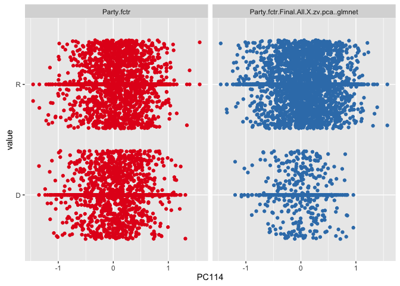

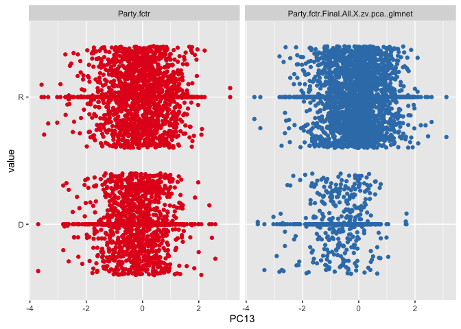

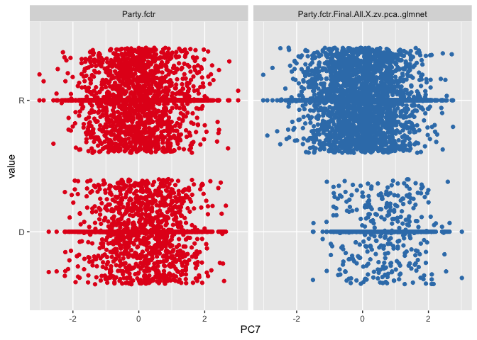

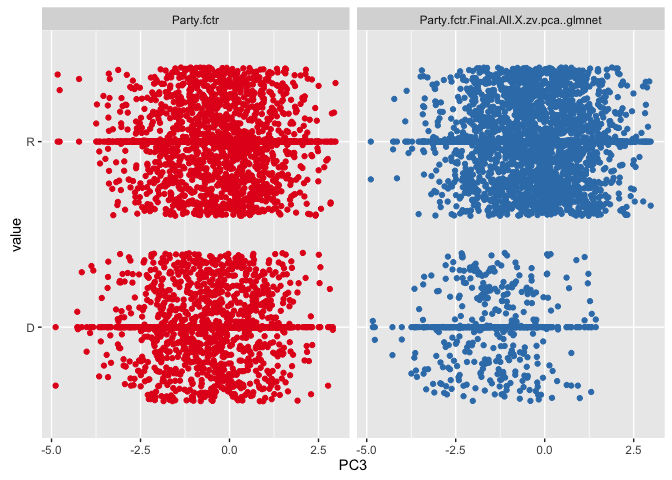

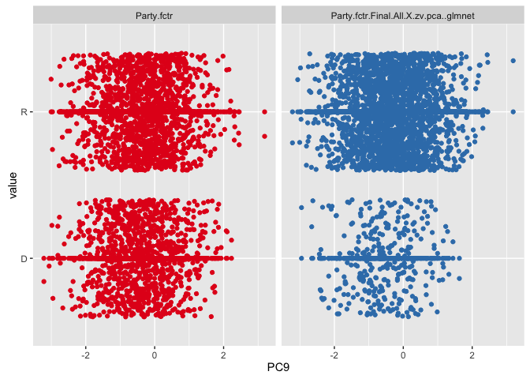

```
## [1] "Min/Max Boundaries: "
##   USER_ID Party.fctr Party.fctr.All.X.zv.pca.rcv.glmnet.prob
## 1    1205          R                               0.7468009
## 2    4467          R                               0.6763040
## 3    5066          R                                      NA
## 4    5651          D                                      NA
##   Party.fctr.All.X.zv.pca.rcv.glmnet
## 1                                  R
## 2                                  R
## 3                               <NA>
## 4                               <NA>
##   Party.fctr.All.X.zv.pca.rcv.glmnet.err
## 1                                  FALSE
## 2                                  FALSE
## 3                                     NA
```

[output cut: 299 more lines]

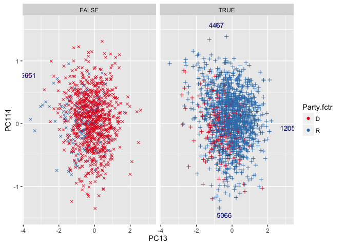

```r
if (glb_is_classification && glb_is_binomial)
    glb_analytics_diag_plots(obs_df=glbObsTrn, mdl_id=glbMdlFinId,
            prob_threshold=glb_models_df[glb_models_df$id == glbMdlSelId,
                                         "opt.prob.threshold.OOB"]) else
    glb_analytics_diag_plots(obs_df=glbObsTrn, mdl_id=glbMdlFinId)
```

```r
dsp_feats_vctr <- c(NULL)
for(var in grep(".imp", names(glb_feats_df), fixed=TRUE, value=TRUE))
    dsp_feats_vctr <- union(dsp_feats_vctr,
                            glb_feats_df[!is.na(glb_feats_df[, var]), "id"])

# print(glbObsTrn[glbObsTrn$UniqueID %in% FN_OOB_ids,
#                     grep(glb_rsp_var, names(glbObsTrn), value=TRUE)])

print(setdiff(names(glbObsTrn), names(glbObsAll)))
```

```
## [1] "Party.fctr.Final.All.X.zv.pca..glmnet.prob"
## [2] "Party.fctr.Final.All.X.zv.pca..glmnet"
## [3] "Party.fctr.Final.All.X.zv.pca..glmnet.err"
## [4] "Party.fctr.Final.All.X.zv.pca..glmnet.err.abs"
## [5] "Party.fctr.Final.All.X.zv.pca..glmnet.is.acc"
```

```r
for (col in setdiff(names(glbObsTrn), names(glbObsAll)))
    # Merge or cbind ?
    glbObsAll[glbObsAll$.src == "Train", col] <- glbObsTrn[, col]

print(setdiff(names(glbObsFit), names(glbObsAll)))
```

```
## character(0)
```

```r
print(setdiff(names(glbObsOOB), names(glbObsAll)))
```

```
## character(0)
```

```r
for (col in setdiff(names(glbObsOOB), names(glbObsAll)))
    # Merge or cbind ?
    glbObsAll[glbObsAll$.lcn == "OOB", col] <- glbObsOOB[, col]

print(setdiff(names(glbObsNew), names(glbObsAll)))
```

```
## character(0)
```

```r
#glb2Sav(); all.equal(savObsAll, glbObsAll); all.equal(sav_models_lst, glb_models_lst)
#load(file = paste0(glbOut$pfx, "dsk_knitr.RData"))
#cmpCols <- names(glbObsAll)[!grepl("\\.Final\\.", names(glbObsAll))]; all.equal(savObsAll[, cmpCols], glbObsAll[, cmpCols]); all.equal(savObsAll[, "H.P.http"], glbObsAll[, "H.P.http"]);

replay.petrisim(pn = glb_analytics_pn,
    replay.trans = (glb_analytics_avl_objs <- c(glb_analytics_avl_objs,
        "data.training.all.prediction","model.final")), flip_coord = TRUE)
```

```
## 0.0000   multiple enabled transitions:  data.training.all data.new model.selected model.final data.training.all.prediction   firing:  data.training.all.prediction
## 1.0000    5   3 0 0 1
```

```
## 1.0000   multiple enabled transitions:  data.training.all data.new model.selected model.final data.training.all.prediction   firing:  model.final
## 2.0000    4   3 0 1 1
```

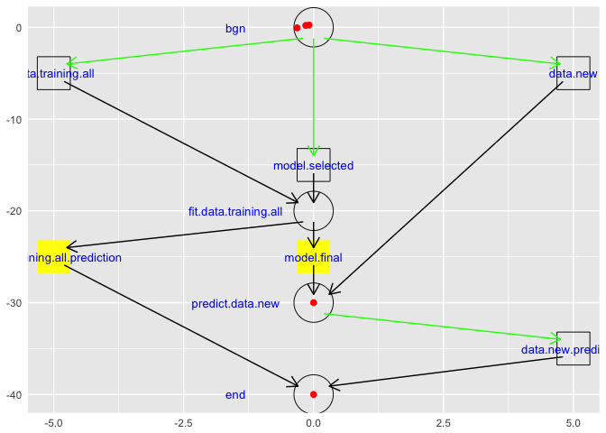

```r
glb_chunks_df <- myadd_chunk(glb_chunks_df, "predict.data.new", major.inc = TRUE)
```

```
##               label step_major step_minor label_minor    bgn    end
## 2 fit.data.training          1          1           1 23.043 33.571
## 3  predict.data.new          2          0           0 33.571     NA
##   elapsed
## 2  10.528
## 3      NA
```

## Step `2.0: predict data new`

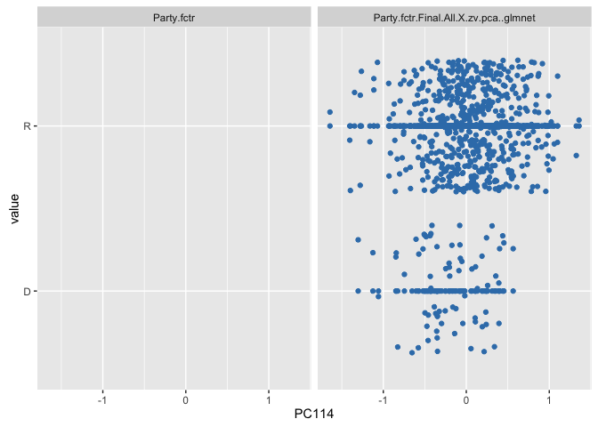

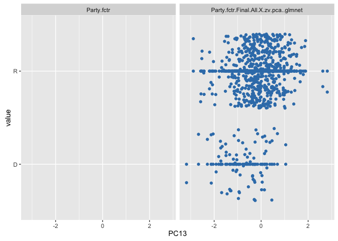

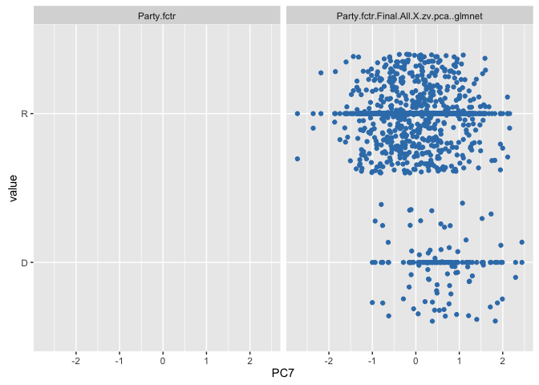

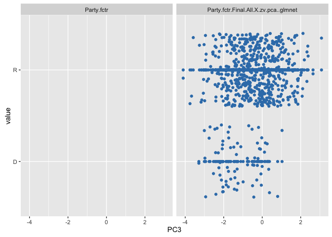

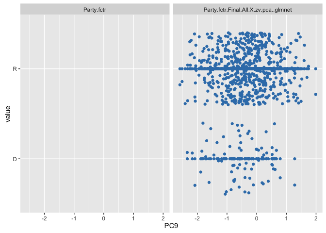

[output not shown]

```
## [1] "Stacking file Votes_Ensemble_cnk06_out_fin.csv to prediction outputs..."
```

```
## [1] 0.5
```

```
## [1] "glbMdlSelId: All.X#zv.pca#rcv#glmnet"
```

```
## [1] "glbMdlFinId: Final.All.X#zv.pca##glmnet"
```

```
## [1] "Cross Validation issues:"
##        MFO###myMFO_classfr  Random###myrandom_classfr
##                          0                          0
## Max.cor.Y.rcv.1X1###glmnet Final.All.X#zv.pca##glmnet
##                          0                          0
```